# WorldCup

```python
# Import the libraries
import pandas as pd
import matplotlib.pyplot as plt
import seaborn as sns
import numpy as np
```

```python
# Load the dataset
world_cup_matches = pd.read_csv("C:\\Users\\sarthak.verma\\Downloads\\worldcup\\WorldCupMatches.csv")
world_cup_players = pd.read_csv("C:\\Users\\sarthak.verma\\Downloads\\worldcup\\WorldCupPlayers.csv")
world_cups = pd.read_csv("C:\\Users\\sarthak.verma\\Downloads\\worldcup\\WorldCups.csv")
```

```python
# Summary status
print("Summarise Stats of world_cup_matches :- ")
print(world_cup_matches.describe())
print("\nSummarise Stats of world_cup_players :- ")
print(world_cup_players.describe())
print("\nSummarise Stats of world_cups :- ")
print(world_cups.describe())
```

```
Summarise Stats of world_cup_matches :-
              Year  Home Team Goals  Away Team Goals     Attendance  \
count   852.000000       852.000000       852.000000     850.000000
mean   1985.089202         1.811033         1.022300   45164.800000
std      22.448825         1.610255         1.087573   23485.249247
min    1930.000000         0.000000         0.000000    2000.000000
25%    1970.000000         1.000000         0.000000   30000.000000
50%    1990.000000         2.000000         1.000000   41579.500000
75%    2002.000000         3.000000         2.000000   61374.500000
max    2014.000000        10.000000         7.000000  173850.000000

       Half-time Home Goals  Half-time Away Goals       RoundID       MatchID
count            852.000000            852.000000  8.520000e+02  8.520000e+02
mean               0.708920              0.428404  1.066177e+07  6.134687e+07
std                0.937414              0.691252  2.729613e+07  1.110572e+08
min                0.000000              0.000000  2.010000e+02  2.500000e+01
25%                0.000000              0.000000  2.620000e+02  1.188750e+03
50%                0.000000              0.000000  3.370000e+02  2.191000e+03
75%                1.000000              1.000000  2.497220e+05  4.395006e+07
max                6.000000              5.000000  9.741060e+07  3.001865e+08

Summarise Stats of world_cup_players :-
            RoundID       MatchID  Shirt Number
count  3.778400e+04  3.778400e+04  37784.000000
mean   1.105647e+07  6.362233e+07     10.726022
std    2.770144e+07  1.123916e+08      6.960138
min    2.010000e+02  2.500000e+01      0.000000
25%    2.630000e+02  1.199000e+03      5.000000
50%    3.370000e+02  2.216000e+03     11.000000
75%    2.559310e+05  9.741000e+07     17.000000
max    9.741060e+07  3.001865e+08     23.000000

Summarise Stats of world_cups :-
              Year  GoalsScored  QualifiedTeams  MatchesPlayed  Attendance
count    20.000000    20.000000       20.000000      20.000000    6.000000
mean   1974.800000   118.950000       21.250000      41.800000  635.139667
std      25.582889    32.972836        7.268352      17.218717  228.846941
min    1930.000000    70.000000       13.000000      17.000000  363.000000
25%    1957.000000    89.000000       16.000000      30.500000  429.412250
50%    1976.000000   120.500000       16.000000      38.000000  679.578000
75%    1995.000000   145.250000       26.000000      55.000000  807.009250
max    2014.000000   171.000000       32.000000      64.000000  893.172000
```

```python
# Top n rows
print(world_cup_matches.head(5))
print(world_cup_players.head(5))
print(world_cups.head(5))
```

```
     Year              Datetime    Stage         Stadium         City  \
0  1930.0  13 Jul 1930 - 15:00   Group 1         Pocitos  Montevideo
1  1930.0  13 Jul 1930 - 15:00   Group 4  Parque Central  Montevideo
2  1930.0  14 Jul 1930 - 12:45   Group 2  Parque Central  Montevideo
3  1930.0  14 Jul 1930 - 14:50   Group 3         Pocitos  Montevideo
4  1930.0  15 Jul 1930 - 16:00   Group 1  Parque Central  Montevideo

  Home Team Name  Home Team Goals  Away Team Goals Away Team Name  \
0         France              4.0              1.0         Mexico
1            USA              3.0              0.0        Belgium
2     Yugoslavia              2.0              1.0         Brazil
3        Romania              3.0              1.0           Peru
4      Argentina              1.0              0.0         France

  Win conditions  Attendance  Half-time Home Goals  Half-time Away Goals  \
```

[output cut: 52 more lines]

```python
# Bottom n rows
print(world_cup_matches.tail(5))
print(world_cup_players.tail(5))
print(world_cups.tail(5))
```

```
      Year Datetime Stage Stadium City Home Team Name  Home Team Goals  \
4567   NaN      NaN   NaN     NaN  NaN            NaN              NaN
4568   NaN      NaN   NaN     NaN  NaN            NaN              NaN
4569   NaN      NaN   NaN     NaN  NaN            NaN              NaN
4570   NaN      NaN   NaN     NaN  NaN            NaN              NaN
4571   NaN      NaN   NaN     NaN  NaN            NaN              NaN

      Away Team Goals Away Team Name Win conditions  Attendance  \
4567              NaN            NaN            NaN         NaN
4568              NaN            NaN            NaN         NaN
4569              NaN            NaN            NaN         NaN
4570              NaN            NaN            NaN         NaN
4571              NaN            NaN            NaN         NaN

      Half-time Home Goals  Half-time Away Goals Referee Assistant 1  \
```

[output cut: 38 more lines]

```python
# Find the unique values
print(world_cup_matches.nunique())
print(world_cup_players.nunique())
print(world_cups.nunique())
```

```
Year                     20
Datetime                602
Stage                    23
Stadium                 181
City                    151
Home Team Name           78
Home Team Goals          11
Away Team Goals           7
Away Team Name           83
Win conditions           43
Attendance              622
Half-time Home Goals      7
Half-time Away Goals      6
Referee                 366
Assistant 1             387
Assistant 2             408
RoundID                 101
MatchID                 836
Home Team Initials       77
Away Team Initials       82
dtype: int64
RoundID           101
MatchID           836
Team Initials      82
Coach Name        335
Line-up             2
Shirt Number       24
Player Name      7663
Position            3
Event            1893
dtype: int64
Year              20
Country           15
Winner             9
Runners-Up        10
Third             14
Fourth            16
GoalsScored       17
QualifiedTeams     5
MatchesPlayed      9
Attendance         6
dtype: int64
```

```python
# Check missing values NaN
print(world_cup_matches.isnull().sum())
print(world_cup_players.isnull().sum())
print(world_cups.isnull().sum())
```

```
Year                    3720
Datetime                3720
Stage                   3720
Stadium                 3720
City                    3720
Home Team Name          3720
Home Team Goals         3720
Away Team Goals         3720
Away Team Name          3720
Win conditions          3720
Attendance              3722
Half-time Home Goals    3720
Half-time Away Goals    3720
Referee                 3720
Assistant 1             3720
Assistant 2             3720
RoundID                 3720
MatchID                 3720
Home Team Initials      3720
Away Team Initials      3720
dtype: int64
RoundID              0
MatchID              0
Team Initials        0
Coach Name           0
Line-up              0
Shirt Number         0
Player Name          0
Position         33641
Event            28715
dtype: int64
Year               0
Country            0
Winner             0
Runners-Up         0
Third              0
Fourth             0
GoalsScored        0
QualifiedTeams     0
MatchesPlayed      0
Attendance        14
dtype: int64
```

1. In the WorldCupMatches Table Year, Datetime, Stage, Stadium, City, Home Team Name, Away Team Name, Home Team Initials, Away Team Initials: These columns are essential for context and should not have missing values. We can fill these with placeholders indicating missing data or use forward fill (No Data) if the missing data appears in a sequential context.
2. Home Team Goals, Away Team Goals, Half-time Home Goals, Half-time Away Goals: These are numerical values. For goals, we can assume a missing value implies 0 goals.
3. Win conditions: If the value is missing, it can be assumed that there were no special win conditions, so we can fill it with 'None'.
4. Attendance: Missing attendance can be filled with the median attendance value since it's a reasonable estimate.
5. Referee, Assistant 1, Assistant 2: Fill missing values with 'Unknown' to indicate missing data.
6. In the WorldCupPlayers Table *Position: We'll drop the column if a high percentage of values are missing and it’s not critical for our main analysis.*Event: Similar to the 'Position' column, drop if not critical or fill missing values with 'None'.
7. Drop Rows with Missing RoundID and MatchID: These identifiers are crucial for the integrity of the dataset, and missing values could signify issues with the data collection process. So, rows with missing values in these columns should be dropped to maintain data integrity.
8. Position This column indicates the position played by each player in a match, which is significant for player performance analysis. Since position data is critical for many analyses, filling missing values with a placeholder like 'Unknown' will allows us to retain the data without losing rows.
9. Event This column records specific events related to players in matches (e.g., goals, cards). If an event is not recorded, it might imply that no significant event occurred. Therefore, filling missing values with 'None' can be appropriate.

```python
# Handling Missing Values in WorldCupMatches
# Drop rows with missing RoundID and MatchID since these are crucial identifiers
world_cup_matches.dropna(subset=['RoundID', 'MatchID'], inplace=True)

# Fill missing numerical values with 0 for goals
world_cup_matches['Home Team Goals'].fillna(0, inplace=True)
world_cup_matches['Away Team Goals'].fillna(0, inplace=True)
world_cup_matches['Half-time Home Goals'].fillna(0, inplace=True)
world_cup_matches['Half-time Away Goals'].fillna(0, inplace=True)

# Fill missing numerical values with median for attendance
world_cup_matches['Attendance'].fillna(world_cup_matches['Attendance'].median(), inplace=True)

# Fill missing categorical values with forward fill (for sequential context) or placeholders
world_cup_matches['Year'].fillna('No data', inplace=True)
world_cup_matches['Datetime'].fillna('No data', inplace=True)
world_cup_matches['Stage'].fillna('Unknown', inplace=True)
world_cup_matches['Stadium'].fillna('Unknown', inplace=True)
world_cup_matches['City'].fillna('Unknown', inplace=True)
world_cup_matches['Home Team Name'].fillna('Unknown', inplace=True)
world_cup_matches['Away Team Name'].fillna('Unknown', inplace=True)
world_cup_matches['Win conditions'].fillna('None', inplace=True)
world_cup_matches['Referee'].fillna('Unknown', inplace=True)
world_cup_matches['Assistant 1'].fillna('Unknown', inplace=True)
world_cup_matches['Assistant 2'].fillna('Unknown', inplace=True)
world_cup_matches['Home Team Initials'].fillna('Unknown', inplace=True)
world_cup_matches['Away Team Initials'].fillna('Unknown', inplace=True)

# Handling Missing Values in WorldCupPlayers
# Fill missing categorical values with placeholders
world_cup_players['Coach Name'].fillna('Unknown', inplace=True)

# Impute missing values in 'Position' with 'Unknown'
world_cup_players['Position'].fillna('Unknown', inplace=True)

# Impute missing values in 'Event' with 'None'
world_cup_players['Event'].fillna('None', inplace=True)
```

```python
# Verify that there are no more missing values
print("Missing values after cleaning in WorldCupMatches:")
print(world_cup_matches.isnull().sum())
print("\nMissing values after cleaning in WorldCupPlayers:")
print(world_cup_players.isnull().sum())
```

```
Missing values after cleaning in WorldCupMatches:
Year                    0
Datetime                0
Stage                   0
Stadium                 0
City                    0
Home Team Name          0
Home Team Goals         0
Away Team Goals         0
Away Team Name          0
Win conditions          0
Attendance              0
Half-time Home Goals    0
Half-time Away Goals    0
Referee                 0
Assistant 1             0
Assistant 2             0
RoundID                 0
MatchID                 0
Home Team Initials      0
Away Team Initials      0
dtype: int64

Missing values after cleaning in WorldCupPlayers:
RoundID          0
MatchID          0
Team Initials    0
Coach Name       0
Line-up          0
Shirt Number     0
Player Name      0
Position         0
Event            0
dtype: int64
```

```python
# Ensure correct data types
world_cup_matches['Datetime'] = pd.to_datetime(world_cup_matches['Datetime'])
```

```python
# Check for dulicates
print("Duplicated in table world_cup_matches :- ")
print(world_cup_matches.duplicated())
print("\nDuplicated in table world_cup_players :- ")
print(world_cup_players.duplicated())
print("\nDuplicated in table world_cups :- ")
print(world_cups.duplicated())
```

```
Duplicated in table world_cup_matches :-
0      False
1      False
2      False
3      False
4      False
       ...
847     True
848     True
849     True
850     True
851     True
Length: 852, dtype: bool

Duplicated in table world_cup_players :-
```

[output cut: 35 more lines]

```python
# Remove duplicates
world_cup_matches.drop_duplicates(inplace=True)
world_cup_players.drop_duplicates(inplace=True)
```

```python
# ReCheck for dulicates after treatment
print("Duplicated in table world_cup_matches after treatment :- ")
print(world_cup_matches.duplicated())
print("\nDuplicated in table world_cup_players after treatment :- ")
print(world_cup_players.duplicated())
print("\nDuplicated in table world_cups after treatment :- ")
print(world_cups.duplicated())
```

```
Duplicated in table world_cup_matches after treatment :-
0      False
1      False
2      False
3      False
4      False
       ...
831    False
832    False
833    False
834    False
835    False
Length: 836, dtype: bool

Duplicated in table world_cup_players after treatment :-
```

[output cut: 35 more lines]

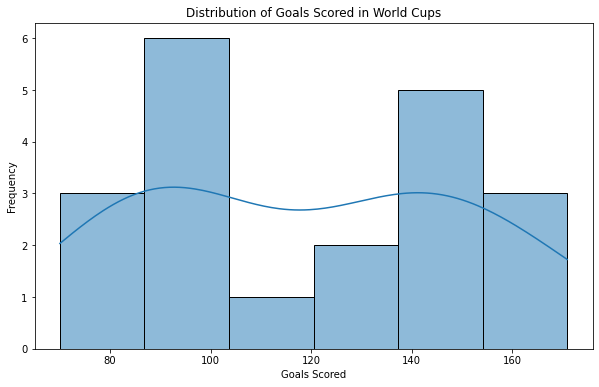

```python
# Univariate Analysis
# Distribution of Goals Scored
plt.figure(figsize=(10, 6))
sns.histplot(world_cups['GoalsScored'], kde=True)
plt.title('Distribution of Goals Scored in World Cups')
plt.xlabel('Goals Scored')
plt.ylabel('Frequency')
plt.show()
```

Goals Scored Distribution:

- The distribution shows a bimodal pattern, suggesting that World Cup matches tend to have either a relatively low or high number of goals scored.
- The peaks are around 80-100 goals and 140-160 goals, indicating that these goal ranges are more common in World Cup tournaments.

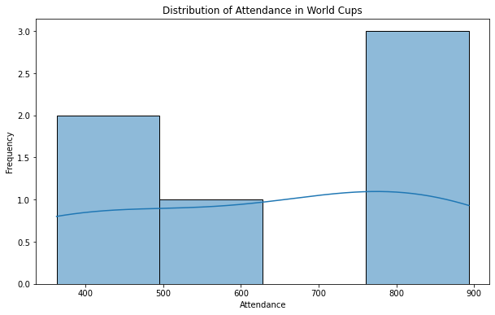

```python
# Distribution of Attendance

# Convert 'Attendance' column to numeric
world_cups['Attendance'] = pd.to_numeric(world_cups['Attendance'], errors='coerce')

plt.figure(figsize=(10, 6))
sns.histplot(world_cups['Attendance'], kde=True)
plt.title('Distribution of Attendance in World Cups')
plt.xlabel('Attendance')
plt.ylabel('Frequency')
plt.show()
```

Attendance Distribution:

- The attendance distribution shows a peak around 700,000 to 800,000, suggesting that World Cup tournaments tend to attract a large number of spectators within this range.
- The distribution is skewed towards higher attendance figures, reflecting the popularity and global appeal of the FIFA World Cup.

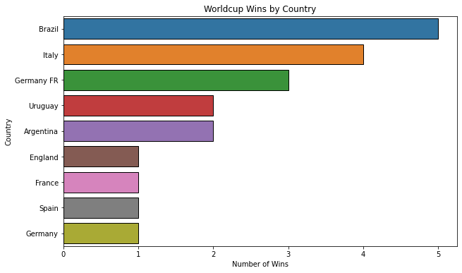

```python
# Bar plot of Winners
plt.figure(figsize=(10, 6))
sns.countplot(y='Winner', data=world_cups, order=world_cups['Winner'].value_counts().index, edgecolor = 'black')
plt.title('Worldcup Wins by Country')
plt.xlabel('Number of Wins')
plt.ylabel('Country')
plt.show()
```

Worldcup Wins by Country:

- Brazil has won the most World Cup titles (5), followed by Italy (4) and Germany (4, including West Germany's 3 wins).
- These three countries have dominated the World Cup, accounting for more than half of the total wins.

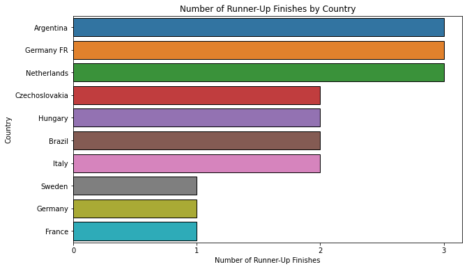

```python
# Bar plot of Runners-Up
plt.figure(figsize=(10, 6))
sns.countplot(y='Runners-Up', data=world_cups, order=world_cups['Runners-Up'].value_counts().index, edgecolor='black')
plt.title('Number of Runner-Up Finishes by Country')
plt.xlabel('Number of Runner-Up Finishes')
plt.ylabel('Country')

# Set x-axis ticks to show whole numbers
max_count = world_cups['Runners-Up'].value_counts().max()
plt.xticks(np.arange(0, max_count + 1, 1))

plt.show()
```

Runner-Up Finishes by Country:

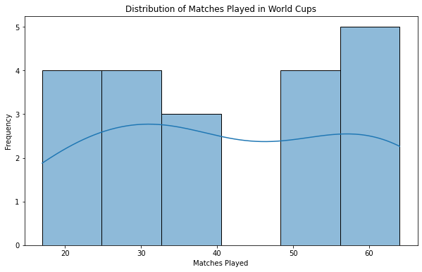

```python
# Distribution of Matches Played
plt.figure(figsize=(10, 6))
sns.histplot(world_cups['MatchesPlayed'], kde=True)
plt.title('Distribution of Matches Played in World Cups')
plt.xlabel('Matches Played')
plt.ylabel('Frequency')
plt.show()
```

Matches Played Distribution:

- The distribution shows peaks around 20-30 matches and 50-60 matches played in World Cup tournaments.
- This could be due to the format of the tournament, with initial group stages followed by knockout rounds, resulting in a higher frequency of matches played within these ranges.

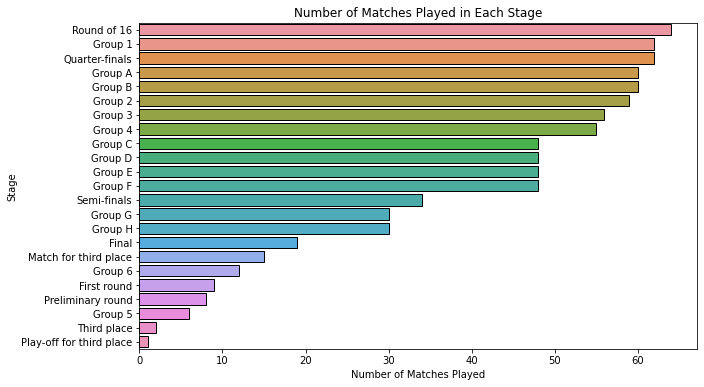

```python
# Distribution of Stages
plt.figure(figsize=(10, 6))
sns.countplot(y='Stage', data=world_cup_matches, order=world_cup_matches['Stage'].value_counts().index, edgecolor = 'black')
plt.title('Number of Matches Played in Each Stage')
plt.xlabel('Number of Matches Played')
plt.ylabel('Stage')
plt.show()
```

Number of Matches Played:

- The Round of 16 and the Quarter-finals stages have the highest number of matches played, indicating the intense competition at these stages.
- The Final match is the culmination of the entire tournament, with only one match played to determine the winner.

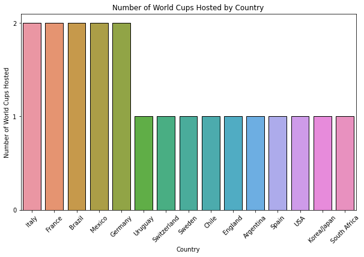

```python
# General Visualizations
# Number of World Cups hosted by each country
host_counts = world_cups['Country'].value_counts()
plt.figure(figsize=(10, 6))
sns.barplot(x=host_counts.index, y=host_counts.values, edgecolor = 'black')
plt.title('Number of World Cups Hosted by Country')
plt.xlabel('Country')
plt.ylabel('Number of World Cups Hosted')
plt.xticks(rotation=45)

# Set y-axis ticks to show whole numbers
max_count = world_cups['Country'].value_counts().max()
plt.yticks(np.arange(0, max_count + 1, 1))

plt.show()
```

Hosting of World Cups:

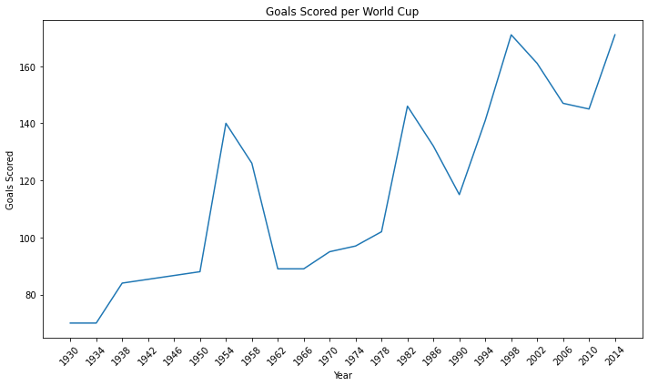

```python
# Goals scored per World Cup
goals_per_wc = world_cups[['Year', 'GoalsScored']]
plt.figure(figsize=(10, 6))
sns.lineplot(x='Year', y='GoalsScored', data=goals_per_wc)
# Set x-axis ticks to include all years
plt.xticks(np.arange(min(goals_per_wc['Year']), max(goals_per_wc['Year'])+1, 4), rotation=45)
plt.title('Goals Scored per World Cup')
plt.xlabel('Year')
plt.ylabel('Goals Scored')
plt.tight_layout()  # Adjust layout to prevent clipping of labels
plt.show()
```

Goals Scored per World Cup:

- The number of goals scored per World Cup has fluctuated over the years, with some tournaments being more goal-friendly than others.
- The trend suggests that the game has evolved, with certain World Cups witnessing more attacking and high-scoring matches.

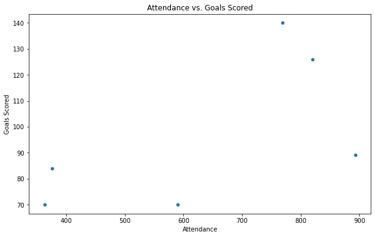

```python
# Scatter plot of Attendance vs. GoalsScored
plt.figure(figsize=(10, 6))
sns.scatterplot(x='Attendance', y='GoalsScored', data=world_cups)
plt.title('Attendance vs. Goals Scored')
plt.xlabel('Attendance')
plt.ylabel('Goals Scored')
plt.show()
```

Attendance vs. Goals Scored:

- There appears to be a positive correlation between attendance and the number of goals scored, suggesting that high-scoring matches attract larger crowds.
- However, the correlation is not perfect, indicating that other factors, such as the teams involved and the stage of the tournament, also influence attendance.

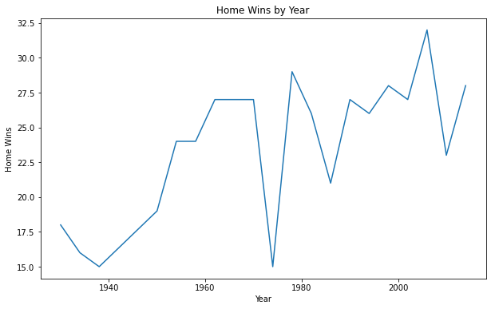

```python
# Match outcomes by year
match_outcomes = world_cup_matches.groupby('Year').apply(lambda x: (x['Home Team Goals'] > x['Away Team Goals']).sum()).reset_index(name='Home Wins')
plt.figure(figsize=(10, 6))
sns.lineplot(x='Year', y='Home Wins', data=match_outcomes)
plt.title('Home Wins by Year')
plt.xlabel('Year')
plt.ylabel('Home Wins')
plt.show()
```

Home Wins by Year:

- The chart shows a cyclical pattern, with some years witnessing more home wins than others.
- This could be attributed to factors like home advantage, team performance, and the overall competitiveness of the tournament in a particular year.

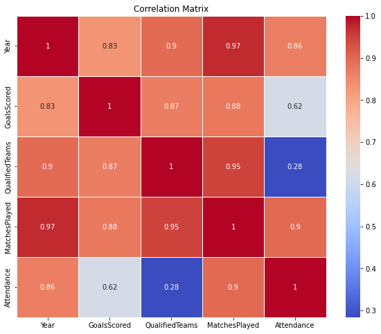

```python
# Correlation heatmap
plt.figure(figsize=(10, 8))
correlation = world_cups.corr()
sns.heatmap(correlation, annot=True, cmap='coolwarm', linewidths=0.5)
plt.title('Correlation Matrix')
plt.show()
```

Correlation Matrix:

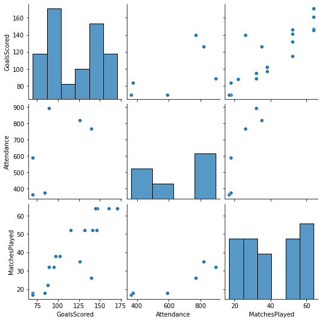

```python
# Pairplot of numerical columns
sns.pairplot(world_cups[['GoalsScored', 'Attendance', 'MatchesPlayed']])
plt.show()
```

Scatterplot:

```
Top Performers

   Year      Winner      Runners-Up    Third      Fourth
0  1930     Uruguay       Argentina      USA  Yugoslavia
1  1934       Italy  Czechoslovakia  Germany     Austria
2  1938       Italy         Hungary   Brazil      Sweden
3  1950     Uruguay          Brazil   Sweden       Spain
4  1954  Germany FR         Hungary  Austria     Uruguay



Host Country Performance

         Country  Wins as Host
0      Argentina             1
1         Brazil             0
2          Chile             0
3        England             1
4         France             1
5        Germany             0
6          Italy             1
7    Korea/Japan             0
8         Mexico             0
9   South Africa             0
10         Spain             0
11        Sweden             0
12   Switzerland             0
13           USA             0
14       Uruguay             1
```

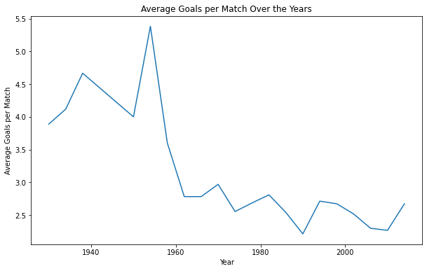

```python
# Statistical Analysis and Detailed Insights
# Top Performers
top_performers = world_cups[['Year', 'Winner', 'Runners-Up', 'Third', 'Fourth']]
print("Top Performers\n")
print(top_performers.head())

# Host Country Impact
host_performance = world_cups.groupby('Country').apply(lambda x: (x['Winner'] == x['Country']).sum()).reset_index(name='Wins as Host')
print("\n\n")
print("Host Country Performance\n")
print(host_performance)
print("\n\n")

# Scoring Analysis
average_goals = world_cup_matches.groupby('Year')[['Home Team Goals', 'Away Team Goals']].mean().reset_index()
average_goals['Total Average Goals'] = average_goals['Home Team Goals'] + average_goals['Away Team Goals']
plt.figure(figsize=(10, 6))
sns.lineplot(x='Year', y='Total Average Goals', data=average_goals)
plt.title('Average Goals per Match Over the Years')
plt.xlabel('Year')
plt.ylabel('Average Goals per Match')
plt.show()
```

Average Goals per Match Over the Years:

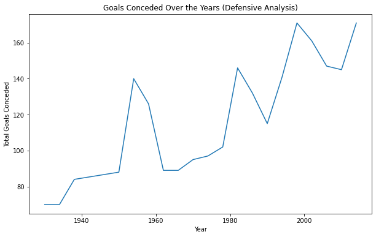

```python
# Defensive Analysis
least_goals_conceded = world_cup_matches.groupby('Year')[['Home Team Goals', 'Away Team Goals']].sum().reset_index()
least_goals_conceded['Total Goals Conceded'] = least_goals_conceded['Home Team Goals'] + least_goals_conceded['Away Team Goals']
plt.figure(figsize=(10, 6))
sns.lineplot(x='Year', y='Total Goals Conceded', data=least_goals_conceded)
plt.title('Goals Conceded Over the Years (Defensive Analysis)')
plt.xlabel('Year')
plt.ylabel('Total Goals Conceded')
plt.show()
```

Goals Conceded Over the Years (Defensive Analysis):

```python
# Match Outcomes
match_outcomes = world_cup_matches.groupby('Home Team Name').apply(lambda x: (x['Home Team Goals'] > x['Away Team Goals']).sum()).reset_index(name='Home Wins')
print(match_outcomes.sort_values(by='Home Wins', ascending=False).head(10))
```

```
   Home Team Name  Home Wins
7          Brazil         58
2       Argentina         39
35          Italy         38
26     Germany FR         29
22        England         22
25        Germany         22
23         France         18
42    Netherlands         17
69        Uruguay         16
61          Spain         16
```

```python
# Hypothesis Testing: Home advantage impact on performance
home_wins = world_cup_matches[world_cup_matches['Home Team Goals'] > world_cup_matches['Away Team Goals']].shape[0]
away_wins = world_cup_matches[world_cup_matches['Away Team Goals'] > world_cup_matches['Home Team Goals']].shape[0]
draws = world_cup_matches[world_cup_matches['Away Team Goals'] == world_cup_matches['Home Team Goals']].shape[0]

print(f'Home Wins: {home_wins}')
print(f'Away Wins: {away_wins}')
print(f'Draws: {draws}')
```

```
Home Wins: 479
Away Wins: 171
Draws: 186
```

```python
from sklearn.model_selection import train_test_split
from sklearn.preprocessing import LabelEncoder
from sklearn.linear_model import LogisticRegression
from sklearn.metrics import accuracy_score, classification_report

# Preprocess the data to handle irregularities in column values
world_cup_matches['Home Team Name'] = world_cup_matches['Home Team Name'].str.strip().str.lower().str.replace('[^\w\s]', '').str.replace('rn', '')
world_cup_matches['Away Team Name'] = world_cup_matches['Away Team Name'].str.strip().str.lower().str.replace('[^\w\s]', '').str.replace('rn', '')
world_cup_matches['Stadium'] = world_cup_matches['Stadium'].str.strip().str.lower().str.replace('[^\w\s]', '').str.replace('rn', '')

# Drop unnecessary columns
world_cup_matches = world_cup_matches[['Home Team Name', 'Away Team Name', 'Stadium', 'Home Team Goals', 'Away Team Goals']]

# Define features and target variable
X = world_cup_matches[['Home Team Name', 'Away Team Name', 'Stadium']]
y = (world_cup_matches['Home Team Goals'] > world_cup_matches['Away Team Goals']).astype(int)  # 1 for home win, 0 otherwise

# Split the data into training and testing sets
X_train, X_test, y_train, y_test = train_test_split(X, y, test_size=0.2, random_state=42)

# Combine training and testing data for label encoding
combined_data = pd.concat([X_train, X_test])

# Encode categorical variables
label_encoder_home = LabelEncoder()
label_encoder_home.fit(combined_data['Home Team Name'])
X_train['Home Team Name'] = label_encoder_home.transform(X_train['Home Team Name'])
X_test['Home Team Name'] = label_encoder_home.transform(X_test['Home Team Name'])

label_encoder_away = LabelEncoder()
label_encoder_away.fit(combined_data['Away Team Name'])
X_train['Away Team Name'] = label_encoder_away.transform(X_train['Away Team Name'])
X_test['Away Team Name'] = label_encoder_away.transform(X_test['Away Team Name'])

label_encoder_stadium = LabelEncoder()
label_encoder_stadium.fit(combined_data['Stadium'])
X_train['Stadium'] = label_encoder_stadium.transform(X_train['Stadium'])
X_test['Stadium'] = label_encoder_stadium.transform(X_test['Stadium'])

# Model training
model = LogisticRegression()
model.fit(X_train, y_train)

# Model evaluation
y_pred = model.predict(X_test)
accuracy = accuracy_score(y_test, y_pred)
print(f'Accuracy: {accuracy:.2f}')

# Classification report
print(classification_report(y_test, y_pred))
```

[output not shown]

```python
# Example prediction
home_team = label_encoder_home.transform(['brazil'])
away_team = label_encoder_away.transform(['germany'])
# Ensure stadium name is consistent with the training data
stadium = label_encoder_stadium.transform(['pocitos'])
prediction = model.predict([[home_team[0], away_team[0], stadium[0]]])
print(f'Prediction: {"Home Win" if prediction[0] == 1 else "Not Home Win"}')
```

```
Prediction: Home Win
```

Overall Summary:

The FIFA World Cup is the pinnacle of international football, capturing the passion and dreams of billions of fans worldwide. The data and insights shed light on the intricate dynamics that shape this prestigious tournament's outcomes. Several factors emerge as crucial determinants of success, ranging from a nation's football culture and player development to strategic gameplay and hosting advantages.

- The historical data reveals that a handful of nations, notably Brazil, Italy, and Germany, have dominated the World Cup, collectively accounting for over half of the total wins. Their consistent performances highlight the significance of a strong footballing tradition, effective youth development programs, and a deep talent pool.
- However, the cyclical nature of home wins and the occasional upsets by underdogs remind us that every World Cup presents an opportunity for new narratives to unfold.

Key Insights:

Key Metrics and Factors Influencing World Cup Wins:

1. Football Culture and Tradition: Nations with a deep-rooted football culture, strong domestic leagues, and well-established youth development systems tend to produce talented players and successful national teams.
2. Player Development and Talent Pool: The quality of a nation's player development programs, scouting networks, and access to top-level coaching and facilities can significantly impact their performance at the World Cup.
3. Tactical Acumen and Strategic Gameplay: Teams with astute tactical approaches, effective game management, and the ability to adapt to different playing styles and conditions often have an advantage in the tournament's high-pressure situations.
4. Home Advantage and Hosting Capabilities: Hosting a World Cup can provide a psychological and logistical boost to the home nation, while also showcasing a country's organizational capabilities and infrastructure.
5. Team Chemistry and Cohesion: A well-gelled team with strong team spirit, effective communication, and a balanced combination of experience and youth can overcome individual talent deficits and perform better than the sum of its parts.
6. Mental Toughness and Resilience: The ability to handle the immense pressure and expectations of the World Cup, maintain focus throughout the tournament, and bounce back from setbacks can separate successful teams from the rest.
7. Luck and Unpredictability: While preparation and skill are paramount, the World Cup's knockout format and the fine margins between success and failure mean that a degree of luck and unpredictability can influence outcomes.

By understanding and analyzing these key metrics and factors, we can provide fans with rich insights, enabling them to appreciate the multifaceted nature of the FIFA World Cup and the relentless pursuit of excellence by teams and players alike.